# How Often Should You Check Your Portfolio?

[Return to Homepage](https://mathiassteilen.github.io/)

[Return to Probability Riddles Section](https://mathiassteilen.github.io/simulation.html)

[figure not shown]

### The Short Answer

The short answer is: as infrequently as possible. The more often you check, the higher the likelihood of noise in the returns pulling your cumulative performance into the red and subsequently causing you unnecessary distress.

### Some Assumptions

For the simulations, normally distributed returns $X$ with mean $\mu = 0.1$ and standard deviation $\sigma = 0.15$ are assumed.

$X \sim \mathcal{N}(\mu = 10\% , \ \sigma = 15\%)$

Summarising this distribution of annual returns, the CDF of the normal distribution will be used giving the investor looking at their portfolio at the end of the year two possible outcomes with probabilities:

##### Positive Portfolio Performance - Annually

```r
1-pnorm(0, mean = 0.1, sd = 0.15)
```

```
## [1] 0.7475075
```

##### Negative Portfolio Performance - Annually

```r
pnorm(0, mean = 0.1, sd = 0.15)
```

```
## [1] 0.2524925
```

### Scaling Effects of Return Probabilities - The General Case

Checking your portfolio under the given assumptions would give you positive news $75\%$ of the time. However, a scale effect exists wherein a higher frequency of checking the portfolio would lead to a lower percentage of positive news, even though the underlying annual performance still remains the same. Checking your portfolio more frequently exposes you to the noise in the market trajectory, that is its variance, and not actually worse performance.

##### Quarterly example

In order to show the scale to the shorter time horizon, the parameters need to be adjusted accordingly. For the quarterly case:

$\mu_Q = \frac{\mu_A}{4}$ and $\sigma_Q = \frac{\sigma_A}{\sqrt{4}}$

Hence we have:

Positive outcome - Quarterly:

```r
1-pnorm(0, mean = 0.1/4, sd = 0.15/sqrt(4))
```

```
## [1] 0.6305587
```

Negative outcome (Quarterly):

```r
pnorm(0, mean = 0.1/4, sd = 0.15/sqrt(4))
```

```
## [1] 0.3694413
```

For one example, the percentage of $\frac{Positive \space News}{Total \space News}$ decreased with an increase the frequency of portfolio checks. The general case will be demonstrated by applying frequencies of $x$ times per year.

### An Illustration for N Portfolio Checks per Year

We have seen that an increase by 4 scales parameters in a way, where more frequent news seem to portray a more negative view on portfolio performance due to higher perceived noise in shorter time frames. In order to show the case for even more updates (up to weekly) per year, a visualisation will be used:

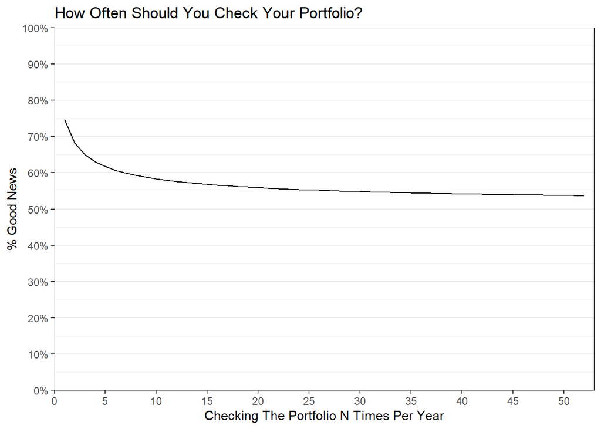

```r
# Initialise data frame
freq_plot_df <- data.frame(matrix(ncol = 2, nrow = 52))
colnames(freq_plot_df) <- c("X_Times_per_Year", "%_Good_News")

# Populate data frame
freq_plot_df <- freq_plot_df %>%
  mutate(X_Times_per_Year = 1:52,
         `%_Good_News` = 1 - pnorm(0,
                                   mean = 0.1/X_Times_per_Year,
                                   sd = 0.15/sqrt(X_Times_per_Year)))
freq_plot_df %>%
ggplot(aes(x = `X_Times_per_Year`, y = `%_Good_News`)) +
  geom_line() +
  labs(title = "How Often Should You Check Your Portfolio?",
       y = "% Good News",
       x = "Checking The Portfolio N Times Per Year") +
  scale_y_continuous(expand = c(0, 0),
                     limits = c(0, 1),
                     breaks = seq(0,1,0.1),
                     labels = scales::percent_format(accuracy = 1)) +
  scale_x_continuous(expand = c(0, 0),
                     limits = c(0, max(freq_plot_df$X_Times_per_Year + 1)),
                     breaks = seq(0,max(freq_plot_df$X_Times_per_Year),5)) +
  theme_bw() +
  theme(panel.grid.major.x = element_blank(),
        panel.grid.minor.x = element_blank())
```

It can be observed, that the percentage of positive news decreases and converges closer to 50% as $Frequency \rightarrow \infty$. The deduction, as outlined by Nassim Taleb is the following:

> “Over the very narrow time increment, the observation will reveal close to nothing. […] Finally, this explains why people who look too closely at randomness burn out, their emotions drained by the series of pangs they experience. Regardless of what people claim, a negative pang is not offset by a positive one (some behavioral economists estimate the effect to be up to 2.5 the magnitude of a positive one); it will lead to an emotional deficit. […] When I see an investor monitoring his portfolio with live prices on his cellular phone or his PalmPilot, I smile and I smile.”

Ruling out parameters which shift the bell curve considerably further to the positive side, the conclusion is that investors should limit their portfolio checks to the absolutely necessary minimum.

A work by [Mathias Steilen](https://www.linkedin.com/in/mathias-steilen/)